# Project: football Team Attendance Variety and Ifootballuencing Factors

# Part3: Machine Learning

```python
import pandas as pd
import matplotlib.pyplot as plt
import numpy as np
from sklearn.decomposition import PCA
from sklearn.pipeline import Pipeline
from sklearn.preprocessing import OneHotEncoder
from sklearn.compose import ColumnTransformer
from sklearn.cluster import AgglomerativeClustering
import seaborn as sns
```

```python
# import the data
football = pd.read_csv('final_dataset.csv')

football.head()
```

|  | team | team_name | year | home_attendance | wins | loss | playoffs | superbowl_winner | win_percentage | state | county | gdp_chained_million_dollar | renovated | stadium_capacity | home_attendance_per_game | home_attendance_rate_per_game |
| --- | --- | --- | --- | --- | --- | --- | --- | --- | --- | --- | --- | --- | --- | --- | --- | --- |
| 0 | Arizona | Cardinals | 2001 | 307315 | 7 | 9 | No Playoffs | 0 | 0.44 | Arizona | Maricopa | 145484.0 | 0 | 73379.0 | 38414.375 | 0.523506 |
| 1 | Arizona | Cardinals | 2002 | 327272 | 5 | 11 | No Playoffs | 0 | 0.31 | Arizona | Maricopa | 150559.0 | 0 | 73379.0 | 40909.000 | 0.557503 |
| 2 | Arizona | Cardinals | 2003 | 288499 | 4 | 12 | No Playoffs | 0 | 0.25 | Arizona | Maricopa | 160947.0 | 0 | 73379.0 | 36062.375 | 0.491454 |
| 3 | Arizona | Cardinals | 2004 | 300267 | 6 | 10 | No Playoffs | 0 | 0.38 | Arizona | Maricopa | 169495.0 | 0 | 71706.0 | 37533.375 | 0.523434 |
| 4 | Arizona | Cardinals | 2005 | 401035 | 5 | 11 | No Playoffs | 0 | 0.31 | Arizona | Maricopa | 184185.0 | 0 | 71706.0 | 50129.375 | 0.699096 |

## Preprocessing Data

- Clean the football dataset, handling missing values, inconsistencies, and any other issues you encounter. You should be able to reuse code from earlier work to help you do this, although you may need to make some modifications.
- Apply various preprocessing techniques such as feature scaling, one-hot encoding, handling categorical variables, and dimensionality reduction.
- Justify the preprocessing choices made, ensuring that they align with the analytical techniques you plan to use later.

### Steps

- Create new attributes: win_percentage_category, gdp_category, home_attendance_rate_category, team_id
- convert playoffs column and renovated columns to boolean values
- deal with missing values
- create pipelines for different types of data
- dimension reduction (PCA)

```python
football.head()
```

|  | team | team_name | year | home_attendance | wins | loss | playoffs | superbowl_winner | win_percentage | state | county | gdp_chained_million_dollar | renovated | stadium_capacity | home_attendance_per_game | home_attendance_rate_per_game |
| --- | --- | --- | --- | --- | --- | --- | --- | --- | --- | --- | --- | --- | --- | --- | --- | --- |
| 0 | Arizona | Cardinals | 2001 | 307315 | 7 | 9 | No Playoffs | 0 | 0.44 | Arizona | Maricopa | 145484.0 | 0 | 73379.0 | 38414.375 | 0.523506 |
| 1 | Arizona | Cardinals | 2002 | 327272 | 5 | 11 | No Playoffs | 0 | 0.31 | Arizona | Maricopa | 150559.0 | 0 | 73379.0 | 40909.000 | 0.557503 |
| 2 | Arizona | Cardinals | 2003 | 288499 | 4 | 12 | No Playoffs | 0 | 0.25 | Arizona | Maricopa | 160947.0 | 0 | 73379.0 | 36062.375 | 0.491454 |
| 3 | Arizona | Cardinals | 2004 | 300267 | 6 | 10 | No Playoffs | 0 | 0.38 | Arizona | Maricopa | 169495.0 | 0 | 71706.0 | 37533.375 | 0.523434 |
| 4 | Arizona | Cardinals | 2005 | 401035 | 5 | 11 | No Playoffs | 0 | 0.31 | Arizona | Maricopa | 184185.0 | 0 | 71706.0 | 50129.375 | 0.699096 |

**Create New Attributes (win_percentage_category, gdp_category, home_attendance_rate_category, team_id)**

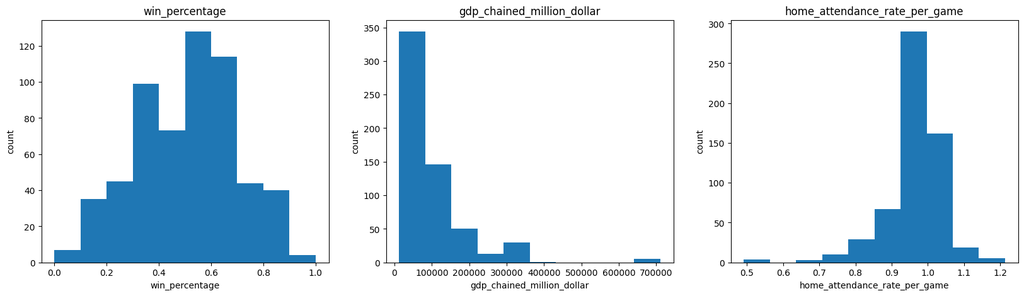

```python
# check the distribution of win_percentage, gdp, and home_attendance_rate
plt.figure(figsize=(20, 5))

plt.subplot(1, 3, 1)
plt.hist(football['win_percentage'])
plt.xlabel('win_percentage')
plt.title('win_percentage')
plt.ylabel('count')

plt.subplot(1, 3, 2)
plt.hist(football['gdp_chained_million_dollar'])
plt.xlabel('gdp_chained_million_dollar')
plt.ylabel('count')
plt.title('gdp_chained_million_dollar')

plt.subplot(1, 3, 3)
plt.hist(football['home_attendance_rate_per_game'])
plt.xlabel('home_attendance_rate_per_game')
plt.ylabel('count')
plt.title('home_attendance_rate_per_game')
```

**win_percentage**

- The distribution is fairly spread out, suggesting a variety in performance among the teams. There's no single peak that stands out significantly, indicating that there isn't a common win percentage among the teams.

**GDP Chained Million Dollar**

- There is a significant skew towards the lower end of the GDP scale, with a peak in the first bin. This indicates that the majority of teams are associated with regions with lower GDP values in chained dollars.

**Home Attendance Rate Per Game**